# Human Development Analysis

Tommaso de Martino matr. 1964326

16 July 2024

## Introduction

The objectives of this analysis are multiple. First, we will try to understand which variables are the most significant in explaining GDP. To do this, we will use three approaches:

1. Linear regression
2. Lasso with Cross-validation
3. Forward stepwise regression with Cross-validation

After that, we will use a Generalized Additive Model to understand the relationship between the dependent variable fertility and the explanatory variables GDP and literacy.

Finally, we will create two classes for Fertility and make predictions using three methods:

1. A logistic model
2. A discriminant analysis
3. KNN algorithm

## Data

The data set “Human Development” contains information about several countries on six variables, all expressed in percentages but the GDP, CO2 and Fertility in 2005.

- Population with access to the internet
- GDP
- Average Intensity of CO2
- Population with cell phone
- Fertility (number of children per woman)
- Literacy (bounded between 0 and 100)

### Libraries

These are the libraries used during the analysis:

- corrplot
- lmtest
- MASS
- car
- glmnet
- leaps
- splines
- gam
- class

### Dataset Analysis

Let’s start by importing the dataset then the name of the first column is modified to make interpretation easier.

```r
# Let's import the dataset
data <- read.csv("/Users/tommasodemar/Documents/Università/Magistrale/ASfF/Progetto/human_development.csv")
head(data)
```

```
##        C1.T INTERNET   GDP  CO2 CELLULAR FERTILITY LITERACY
## 1   Algeria     0.65  6.09  3.0      0.3       2.8     58.3
## 2 Argentina    10.08 11.32  3.8     19.3       2.4     96.9
## 3 Australia    37.14 25.37 18.2     57.4       1.7    100.0
## 4   Austria    38.70 26.73  7.6     81.7       1.3    100.0
## 5   Belgium    31.04 25.52 10.2     74.7       1.7    100.0
## 6    Brazil     4.66  7.36  1.8     16.7       2.2     87.2
```

```r
# Changing the name of the first column
names(data)[1] <- "COUNTRY"
head(data)
```

```
##     COUNTRY INTERNET   GDP  CO2 CELLULAR FERTILITY LITERACY
## 1   Algeria     0.65  6.09  3.0      0.3       2.8     58.3
## 2 Argentina    10.08 11.32  3.8     19.3       2.4     96.9
## 3 Australia    37.14 25.37 18.2     57.4       1.7    100.0
## 4   Austria    38.70 26.73  7.6     81.7       1.3    100.0
## 5   Belgium    31.04 25.52 10.2     74.7       1.7    100.0
## 6    Brazil     4.66  7.36  1.8     16.7       2.2     87.2
```

Now we have a first look at the characteristics of the dataset, check for missing values.

```r
# Inspect the final dataset
str(data)
```

```
## 'data.frame':    39 obs. of  7 variables:
##  $ COUNTRY  : chr  "Algeria" "Argentina" "Australia" "Austria" ...
##  $ INTERNET : num  0.65 10.08 37.14 38.7 31.04 ...
##  $ GDP      : num  6.09 11.32 25.37 26.73 25.52 ...
##  $ CO2      : num  3 3.8 18.2 7.6 10.2 1.8 14.4 4.2 2.3 9.3 ...
##  $ CELLULAR : num  0.3 19.3 57.4 81.7 74.7 16.7 36.2 34.2 11 74 ...
##  $ FERTILITY: num  2.8 2.4 1.7 1.3 1.7 2.2 1.5 2.4 1.8 1.8 ...
##  $ LITERACY : num  58.3 96.9 100 100 100 87.2 100 95.7 78.7 100 ...
```

```r
summary(data)
```

```
##    COUNTRY             INTERNET           GDP              CO2
##  Length:39          Min.   : 0.090   Min.   : 0.790   Min.   : 0.300
##  Class :character   1st Qu.: 2.565   1st Qu.: 6.045   1st Qu.: 3.050
##  Mode  :character   Median :20.140   Median :17.440   Median : 6.800
##                     Mean   :21.140   Mean   :15.993   Mean   : 6.805
##                     3rd Qu.:37.890   3rd Qu.:25.360   3rd Qu.: 9.500
##                     Max.   :51.630   Max.   :34.320   Max.   :19.700
##     CELLULAR       FERTILITY        LITERACY
##  Min.   : 0.30   Min.   :1.100   Min.   : 26.90
##  1st Qu.:11.15   1st Qu.:1.650   1st Qu.: 81.35
##  Median :36.20   Median :2.000   Median : 96.90
##  Mean   :41.84   Mean   :2.379   Mean   : 86.33
##  3rd Qu.:74.35   3rd Qu.:2.650   3rd Qu.:100.00
##  Max.   :90.70   Max.   :7.000   Max.   :100.00
```

```r
# Although it is easy to check for missing data manually, let's do it using this function
missing_data <- sum(is.na(data))
print(missing_data)
```

```
## [1] 0
```

### Let’s analyse the paired relations

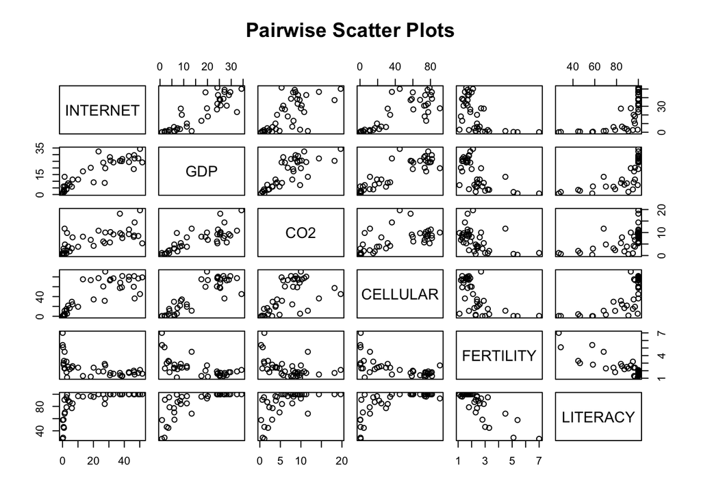

```r
pairs(data[, -1], main = "Pairwise Scatter Plots")
```

GDP seems to be positively associated with INTERNET, CO2 and CELLULAR

## Linear Regression

A good way to start is to fit a model including all the variables and look at the more significant ones

## Model 1

Let’s fit the following model
$$\text{GDP} = \beta_0 + \beta_1 \cdot \text{INTERNET} + \beta_2 \cdot
\text{CO2} + \beta_3 \cdot \text{CELLULAR} + \beta_4 \cdot
\text{FERTILITY} + \beta_5 \cdot \text{LITERACY} + \epsilon$$

```r
model1 <- lm(GDP ~ INTERNET + CO2 + CELLULAR + FERTILITY + LITERACY, data = data)
summary(model1)
```

```
##
## Call:
## lm(formula = GDP ~ INTERNET + CO2 + CELLULAR + FERTILITY + LITERACY,
##     data = data)
##
## Residuals:
##     Min      1Q  Median      3Q     Max
## -6.3847 -1.4265  0.1358  1.6359  7.9605
##
## Coefficients:
##             Estimate Std. Error t value Pr(>|t|)
## (Intercept)  3.37528    5.88373   0.574  0.57009
## INTERNET     0.17280    0.05722   3.020  0.00485 **
## CO2          0.74368    0.16074   4.627 5.52e-05 ***
## CELLULAR     0.14120    0.03178   4.443 9.42e-05 ***
## FERTILITY   -0.47429    0.78622  -0.603  0.55046
## LITERACY    -0.01013    0.05486  -0.185  0.85460
## ---
## Signif. codes:  0 '***' 0.001 '**' 0.01 '*' 0.05 '.' 0.1 ' ' 1
##
## Residual standard error: 3.303 on 33 degrees of freedom
## Multiple R-squared:  0.9156, Adjusted R-squared:  0.9028
## F-statistic: 71.61 on 5 and 33 DF,  p-value: < 2.2e-16
```

There are 2 variables which are non statistically significant. The problem can be caused by the violations of some Linear Regression assumptions. In order to investigate into this issue let’s analyse some residual plots

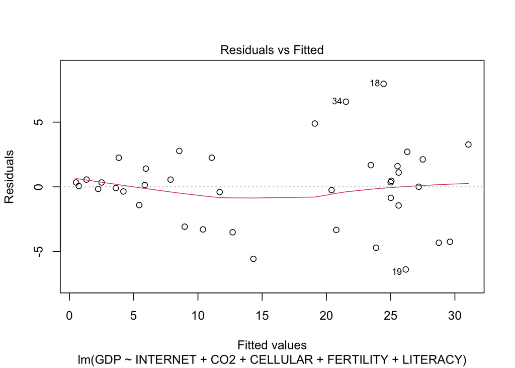

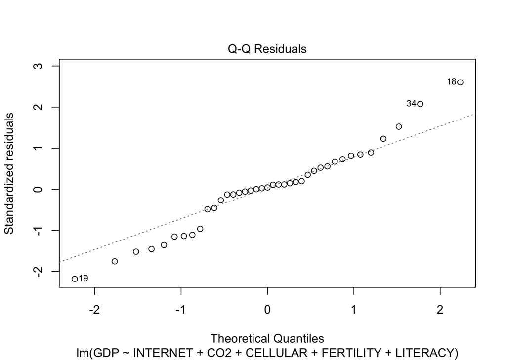

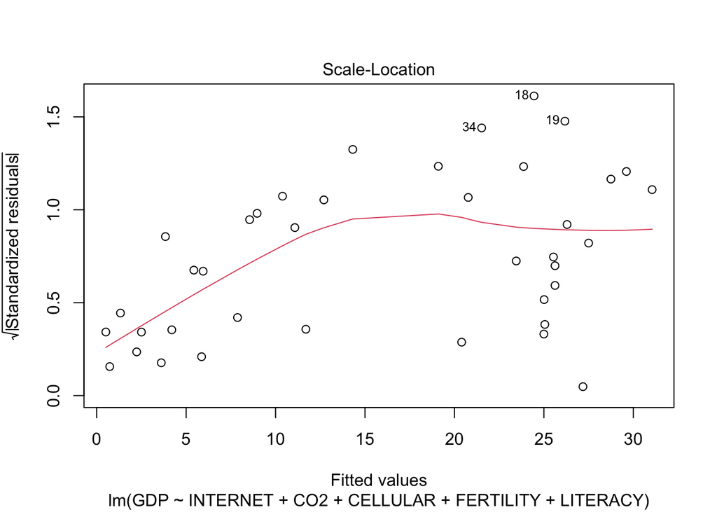

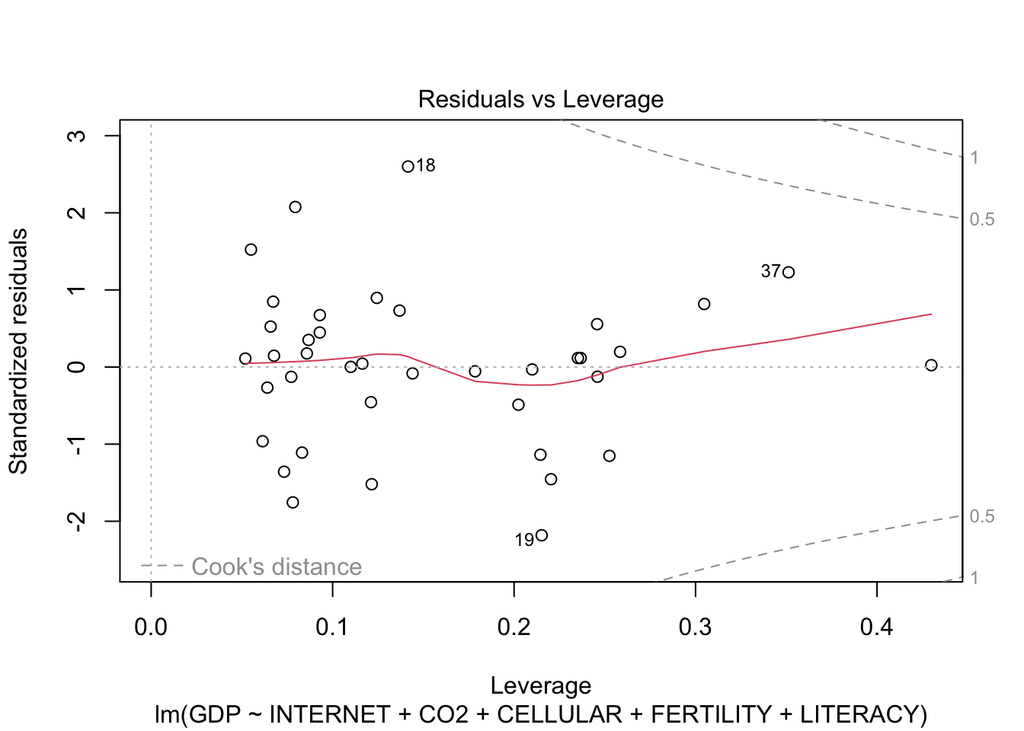

```r
plot(model1)
```

## Heteroskedasticity

In our first plot “Residuals vs Fitted”, we can notice a funnel shape. It may indicate the presence of heteroskedasticity (non-constant variances in the errors).

#### Breusch-Pagan test

This test involves using a linear regression of the residuals squared and using a chi-square test to test the null hypothesis that heteroskedasticity is NOT present (i.e. homoskedastic) against the alternative hypothesis that heteroskedasticity is present.

So let’s proceed regressing the residual squared over the regressor in order to create a variance function and access to its summary. Then the Breusch-Pagan test is computed as follows:

$$BP\_test = R^2 \times N$$

```r
resi <- model1$residuals
var.func <- lm(resi^2 ~ INTERNET + CO2 + CELLULAR + FERTILITY + LITERACY, data=data)
summary(var.func)
```

```
##
## Call:
## lm(formula = resi^2 ~ INTERNET + CO2 + CELLULAR + FERTILITY +
##     LITERACY, data = data)
##
## Residuals:
##     Min      1Q  Median      3Q     Max
## -17.264  -8.565  -1.180   3.438  41.550
##
## Coefficients:
##             Estimate Std. Error t value Pr(>|t|)
## (Intercept) -21.2891    23.9336  -0.890    0.380
## INTERNET     -0.3360     0.2328  -1.444    0.158
## CO2           0.6585     0.6539   1.007    0.321
## CELLULAR      0.2765     0.1293   2.139    0.040 *
## FERTILITY     2.9942     3.1982   0.936    0.356
## LITERACY      0.1674     0.2232   0.750    0.458
## ---
## Signif. codes:  0 '***' 0.001 '**' 0.01 '*' 0.05 '.' 0.1 ' ' 1
##
## Residual standard error: 13.44 on 33 degrees of freedom
## Multiple R-squared:  0.2291, Adjusted R-squared:  0.1123
## F-statistic: 1.961 on 5 and 33 DF,  p-value: 0.1107
```

```r
# Breusch-Pagan is computed -> R2*N
N <- nrow(data)
R2 <- summary(var.func)$r.squared
BP_test_statistic <- R2 * N
BP_test_statistic
```

```
## [1] 8.933427
```

Then we must compare it to the associated chi-square critical value

```r
dof <- length(coef(var.func)) -1 # We subtract 1 to exclude the intercept
BP_critical_value <- qchisq(0.95, dof)
BP_critical_value
```

```
## [1] 11.0705
```

Since BP_test_statistic < BP_critical_value we fail to reject the null hypothesis and so there is no evidence of heteroscedasticity

We can also use directly the function from the “lmtest package”

```r
bptest(model1)
```

```
##
##  studentized Breusch-Pagan test
##
## data:  model1
## BP = 8.9334, df = 5, p-value = 0.1117
```

And since p-value > 0.05 and there is no evidence to reject H0 we end up with the same conclusion: no evidence of heteroscedasticity.

## Normality

In the “Q-Q Residuals” plot we can see how some points deviate from the reference line, this may indicate the non-normality of residuals

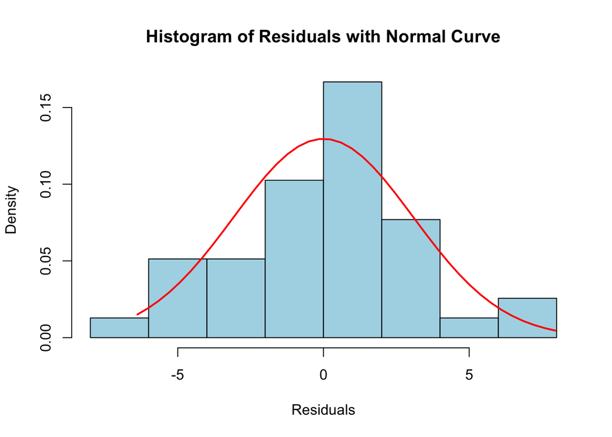

```r
hist(resi, col = "lightblue", main = "Histogram of Residuals with Normal Curve", xlab = "Residuals", ylab = "Density", prob = TRUE)
xfit <- seq(min(resi), max(resi), length = 40)
yfit <- dnorm(xfit, mean = mean(resi), sd = sd(resi))
lines(xfit, yfit, col = "red", lwd = 2)
```

The histogram is not so consistent with the normality assumption but it may be due to the sample size which is not so large

To investigate this issue we can perform the Shapiro-Wilk test

### Shapiro-Wilk

tests the null hypothesis that the data was drawn from a normal distribution

```r
shapiro.test(resi)
```

```
##
##  Shapiro-Wilk normality test
##
## data:  resi
## W = 0.96585, p-value = 0.2777
```

Since p-value > 0.05 we cannot reject H0 and so we conclude that residuals do NOT deviate from normality

### Residual correlation

Or we can just look at the correlation between observed residuals and expected residuals under normality.

```r
ols_test_correlation(model1)
```

```
## [1] 0.9813484
```

## Outliers and High Leverage Points

To investigate about the Outliers or abour High Leverage Points we can look at the plot of “Studentized Residuals” and the plot of “Residuals vs Leverage” respectively

#### Outliers: Studentized Residuals

For the studentized residuals the residual is divided by its own estimated standard error,which includes an adjustment for the leverage of the observation. This makes studentized residuals more precise for detecting outliers and influential points. As a rule of thumb an observations whose studentized residuals are greater than 3 in absolute value are possible outliers

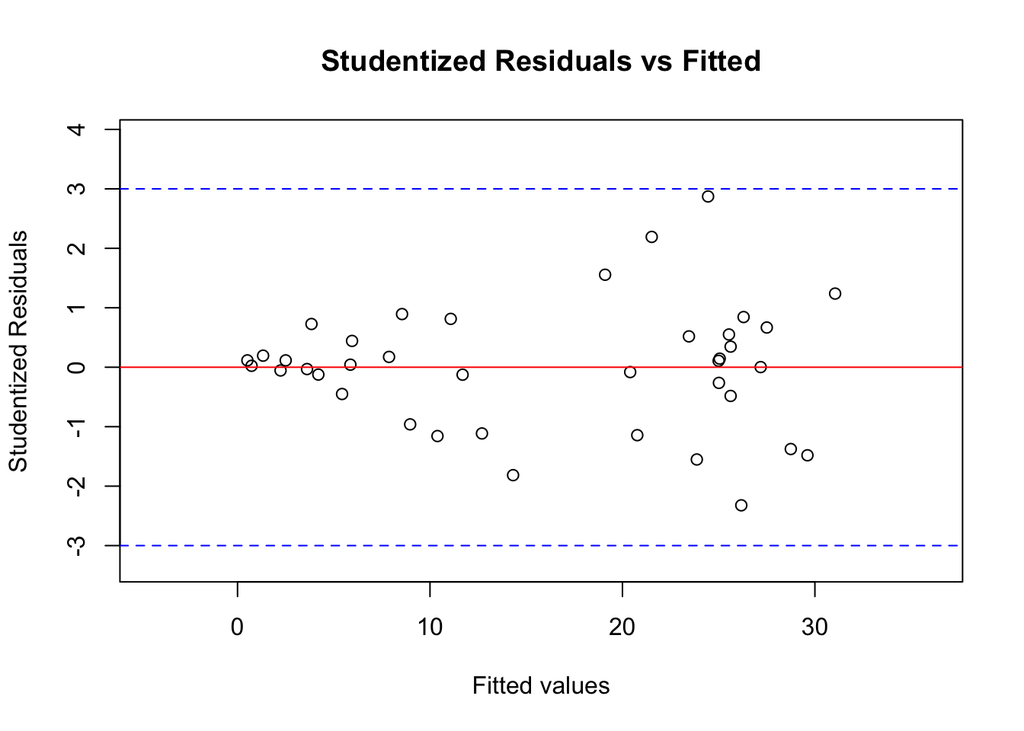

```r
plot(model1$fitted.values, rstudent(model1),
     xlab = "Fitted values", ylab = "Studentized Residuals",
     main = "Studentized Residuals vs Fitted",
     xlim = range(model1$fitted.values) + c(-5, 5),
     ylim = range(rstudent(model1)) + c(-1, 1))
abline(h = 0, col = "red")
abline(h = c(-3, 3), col = "blue", lty = 2)
```

### High-Leverage Points

in order to quantify an observation’s leverage, we compute the leverage statistic. In the case of a Multiple Linear Regression the leverage h(i) for the i-th observation is calculated using the hat matrix

$$H = X (X'X)^{-1} X'$$

The diagonal elements h(ii) of the hat matrix H represent the leverage values for each observation The “hatvalues” function in R calculates these leverage values directly from a fitted model As a rule of thumb we can identify an observation as a High-Leverage Point if it exceeds the average leverage that corresponds to

$$h_{ii} > 2 \left( \frac{p + 1}{n} \right)$$

```r
leverage_values <- hatvalues(model1)
# Average leverage
n <- length(model1$fitted.values)
p <- length(coefficients(model1)) - 1 # no intercept
average_leverage <- (p + 1) / n
high_leverage_points <- which(leverage_values > 2 * average_leverage)
print(high_leverage_points)
```

```
## 37 39
## 37 39
```

So we have identified these 2 observations

## Model 2

Let’s try to re-fit our model without the high leverage points

```r
clean_data <- data[-high_leverage_points, ]
model2 <- lm(GDP ~ INTERNET + CO2 + CELLULAR + FERTILITY + LITERACY, data = clean_data)
summary(model2)
```

```
##
## Call:
## lm(formula = GDP ~ INTERNET + CO2 + CELLULAR + FERTILITY + LITERACY,
##     data = clean_data)
##
## Residuals:
##     Min      1Q  Median      3Q     Max
## -6.4788 -1.6528  0.2489  1.9966  7.9763
##
## Coefficients:
##             Estimate Std. Error t value Pr(>|t|)
## (Intercept)  3.95810    6.02031   0.657 0.515739
## INTERNET     0.15534    0.05951   2.610 0.013810 *
## CO2          0.65081    0.17898   3.636 0.000992 ***
## CELLULAR     0.15507    0.03430   4.521 8.43e-05 ***
## FERTILITY   -0.57202    0.89616  -0.638 0.527964
## LITERACY    -0.01090    0.05534  -0.197 0.845186
## ---
## Signif. codes:  0 '***' 0.001 '**' 0.01 '*' 0.05 '.' 0.1 ' ' 1
##
## Residual standard error: 3.329 on 31 degrees of freedom
## Multiple R-squared:  0.9071, Adjusted R-squared:  0.8922
## F-statistic: 60.57 on 5 and 31 DF,  p-value: 4.51e-15
```

But the model does not improve so we can consider our previous model

## Multicollinearity

### Correlation matrix

```r
cor_matrix <- cor(data[, -1])
print(cor_matrix)
```

```
##             INTERNET        GDP        CO2   CELLULAR  FERTILITY   LITERACY
## INTERNET   1.0000000  0.8881536  0.6800748  0.8179625 -0.5507279  0.6694976
## GDP        0.8881536  1.0000000  0.7856680  0.8743511 -0.6145094  0.7168206
## CO2        0.6800748  0.7856680  1.0000000  0.5627181 -0.4643867  0.5740491
## CELLULAR   0.8179625  0.8743511  0.5627181  1.0000000 -0.6071015  0.7085663
## FERTILITY -0.5507279 -0.6145094 -0.4643867 -0.6071015  1.0000000 -0.8357891
## LITERACY   0.6694976  0.7168206  0.5740491  0.7085663 -0.8357891  1.0000000
```

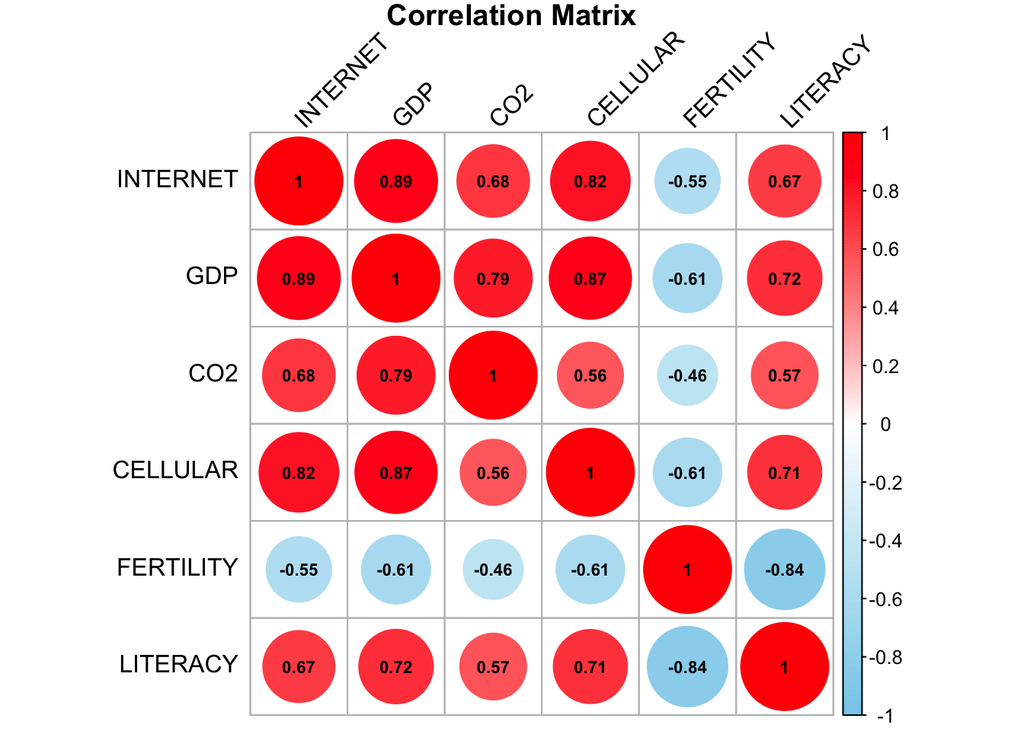

```r
corrplot(cor_matrix, method = "circle", type = "full",
         tl.col = "black", tl.srt = 45,
         col = colorRampPalette(c("#87CEEB", "white", "red"))(200),
         addCoef.col = "black", number.cex = 0.7,
         mar = c(0,0,1,0),
         title = "Correlation Matrix")
```

We can notice that we have high correlations between predictors

1. STRONG POSITIVE CORRELATIONS
- INTERNET and CELLULAR (0.82)
- INTERNET and CO2 (0.68): higher population with internet access is associated with higher CO2 emissions (may be due to servers emissions)
- INTERNET and LITERACY (0.67): higher population with internet access correlates with higher literacy rates.
- CELLULAR and LITERACY (0.71): strong positive correlation between population with cell phone and literacy rates
2. STRONG NEGATIVE CORRELATIONS
- FERTILITY and LITERACY (-0.84): higher literacy rates are strongly associated with lower children per woman
- FERTILITY and CELLULAR (-0.61): higher population with cell phone is associated with lower fertility rates
3. MODERATE CORRELATIONS
- CO2 and CELLULAR (0.56)
- FERTILITY and CO2 (-0.46)
- CO2 and LITERACY (0.57)
- FERTILITY and INTERNET (-0.55): higher population with internet access is associated with lower children per woman

### Variance inflation factor

Another way to assess multicollinearity is to compute the ‘’variance inflation factor’’ (VIF) The VIF is the ratio of the variance of ˆβj when fitting the full model divided by the variance of ˆβj if fit on its own. The smallest possible value for VIF is 1, which indicates the complete absence of collinearity.

```r
vif_values <- vif(model1)
print(vif_values)
```

```
##  INTERNET       CO2  CELLULAR FERTILITY  LITERACY
##  3.888081  1.965031  3.556965  3.336616  4.525971
```

VIF are not so high, as a threshold we can consider a VIF value that exceeds 5 or 10 to detect a problematic amount of collinearity.

## 2 other models

So let’s simply fit two other models, each one excluding one of the non-significant variables

#### Model 3 and 4

```r
model3 <- lm(GDP ~ INTERNET + CO2 + CELLULAR + FERTILITY, data = data)
summary(model3)
```

```
##
## Call:
## lm(formula = GDP ~ INTERNET + CO2 + CELLULAR + FERTILITY, data = data)
##
## Residuals:
##     Min      1Q  Median      3Q     Max
## -6.3997 -1.3920  0.2052  1.6550  7.9407
##
## Coefficients:
##             Estimate Std. Error t value Pr(>|t|)
## (Intercept)  2.36669    2.15926   1.096  0.28075
## INTERNET     0.17172    0.05611   3.061  0.00429 **
## CO2          0.73844    0.15595   4.735 3.78e-05 ***
## CELLULAR     0.13991    0.03056   4.578 6.01e-05 ***
## FERTILITY   -0.37084    0.54386  -0.682  0.49994
## ---
## Signif. codes:  0 '***' 0.001 '**' 0.01 '*' 0.05 '.' 0.1 ' ' 1
##
## Residual standard error: 3.256 on 34 degrees of freedom
## Multiple R-squared:  0.9155, Adjusted R-squared:  0.9056
## F-statistic: 92.12 on 4 and 34 DF,  p-value: < 2.2e-16
```

```r
model4 <- lm(GDP ~ INTERNET + CO2 + CELLULAR + LITERACY, data = data)
summary(model4)
```

```
##
## Call:
## lm(formula = GDP ~ INTERNET + CO2 + CELLULAR + LITERACY, data = data)
##
## Residuals:
##     Min      1Q  Median      3Q     Max
## -6.7425 -1.1780  0.4171  1.7239  7.8314
##
## Coefficients:
##             Estimate Std. Error t value Pr(>|t|)
## (Intercept)  0.20565    2.62306   0.078  0.93797
## INTERNET     0.17118    0.05662   3.023  0.00473 **
## CO2          0.74154    0.15919   4.658 4.75e-05 ***
## CELLULAR     0.14250    0.03141   4.537 6.79e-05 ***
## LITERACY     0.01344    0.03814   0.353  0.72663
## ---
## Signif. codes:  0 '***' 0.001 '**' 0.01 '*' 0.05 '.' 0.1 ' ' 1
##
## Residual standard error: 3.272 on 34 degrees of freedom
## Multiple R-squared:  0.9147, Adjusted R-squared:  0.9046
## F-statistic: 91.13 on 4 and 34 DF,  p-value: < 2.2e-16
```

But also doing this both variables remain non-significant

## Final model

Since for interpretations sometimes simpler model are better let’s remove both of them

$$\text{GDP} = \beta_0 + \beta_1 \cdot \text{INTERNET} + \beta_2 \cdot
\text{CO}_2 + \beta_3 \cdot \text{CELLULAR} + \epsilon$$

```r
model5 <- lm(GDP ~ INTERNET + CO2 + CELLULAR, data = data)
summary(model5)
```

```
##
## Call:
## lm(formula = GDP ~ INTERNET + CO2 + CELLULAR, data = data)
##
## Residuals:
##     Min      1Q  Median      3Q     Max
## -6.9123 -1.3214  0.1547  1.7503  7.8090
##
## Coefficients:
##             Estimate Std. Error t value Pr(>|t|)
## (Intercept)  1.06034    0.98836   1.073  0.29069
## INTERNET     0.17313    0.05564   3.112  0.00369 **
## CO2          0.75440    0.15300   4.931 1.98e-05 ***
## CELLULAR     0.14674    0.02865   5.121 1.11e-05 ***
## ---
## Signif. codes:  0 '***' 0.001 '**' 0.01 '*' 0.05 '.' 0.1 ' ' 1
##
## Residual standard error: 3.231 on 35 degrees of freedom
## Multiple R-squared:  0.9144, Adjusted R-squared:  0.907
## F-statistic: 124.6 on 3 and 35 DF,  p-value: < 2.2e-16
```

All three variables are significant and positively correlated with the dependent variable

## Lasso and Coss-validation

We will use the package “glmnet”, which does not use the model formula language, so we need to set up an x and a y

```r
# We need to exclude the first column (COUNTRY) for the predictors and specify GDP as the response
x <- model.matrix(GDP ~ . - COUNTRY, data = data)[, -1]
y <- data$GDP
```

### Lasso

In lasso we want to minimize this quantity instead of the classic RSS

$$\sum_{i=1}^{n} \left( y_i - \beta_0 - \sum_{j=1}^{p} \beta_j x_{ij}
\right)^2 + \lambda \sum_{j=1}^{p} |\beta_j| = \text{RSS} + \lambda
\sum_{j=1}^{p} |\beta_j|.$$

where

- $\lambda \sum_{j=1}^{p} |\beta_j|$ is the shrinkage penalty. It is small when the $\beta$s are close to zero. It has the effect of shrinking the estimates of $\beta_j$ towards zero.
- λ = tunning parameter (to be determined separately). It serves to control the relative impact of RSS and $\sum_{j=1}^{p} |\beta_j|$ on the regression coefficient estimates

the Lasso uses an $\ell_1$ penalty instead of an $\ell_2$ (the rifge one) penalty. The $\ell_1$ norm of a coefficient vector $\beta$ is given by:

$$\| \beta \|_1 = \sum_{j} |\beta_j|.$$

As with ridge regression, the lasso shrinks the coefficient estimates towards zero. However, in the case of the lasso, the penalty has the effect of forcing some of the coefficient estimates to be exactly equal to zero when the tuning parameter λ is sufficiently large

This means that with lasso we are able to perform “variable selection”

Unlike least squares, which generates only one set of coefficient estimates, lasso regression will produce a different set of coefficient estimates, $\beta$ , for each value of λ

#### ATTENTION

Lasso yields sparse models, that is, models that involve only a subset of the variables

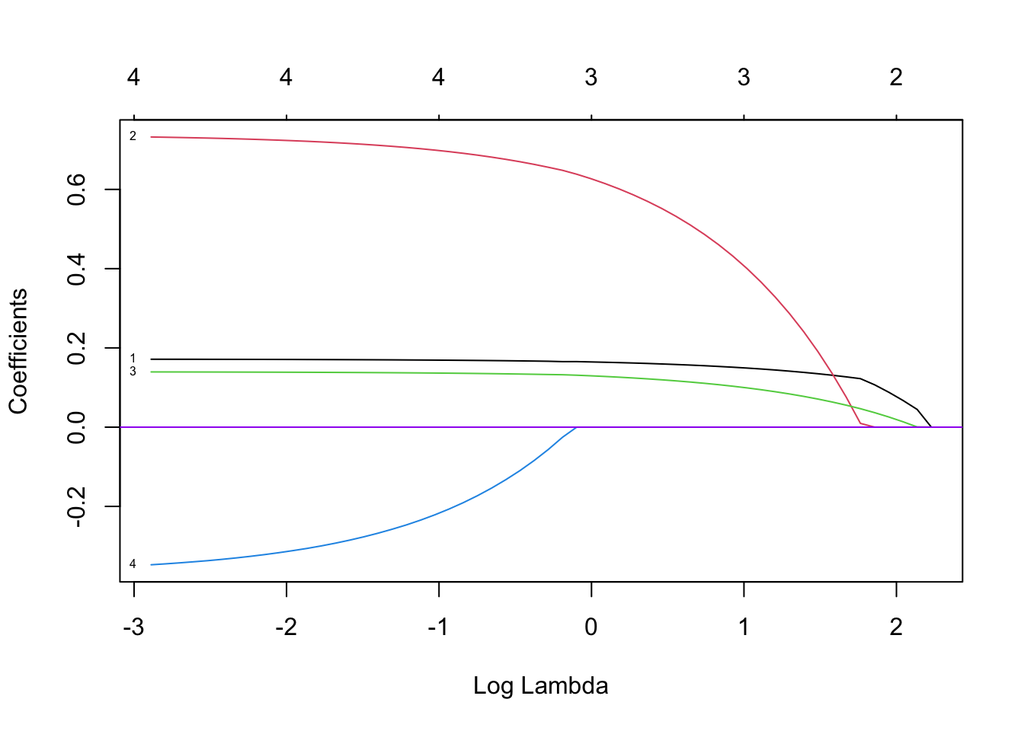

```r
fit.lasso=glmnet(x,y)
plot(fit.lasso,xvar="lambda",label=TRUE)
abline(h=0, col="purple")
```

### Tunning parameter λ

Lasso require a methpod for selecting a value for the tunning parameter λ, CROSS-VALIDATION provides a simple way to tackle this issue

## Cros-Validation

#### k-folds cross validation

This approach involves randomly dividing the set of observations into k groups, or folds, of approximately equal size. The first fold is treated as a validation set, and the method is fit on the remaining k − 1 folds. The mean squared error, MSE1, is then computed on the observations in the held-out fold.

This procedure is repeated k times; each time, a different group of observations is treated as a validation set. This process results in k estimates of the test error, MSE1, MSE2, . . . , MSEk. The k-fold CV estimate is computed by averaging these values

$$\text{CV}(k) = \frac{1}{k} \sum_{i=1}^{k} \text{MSE}_i.$$

#### How many folds?

one typically performs k-fold CV using k = 5 or k = 10

## k=10 folds

R as default uses k=10 folds

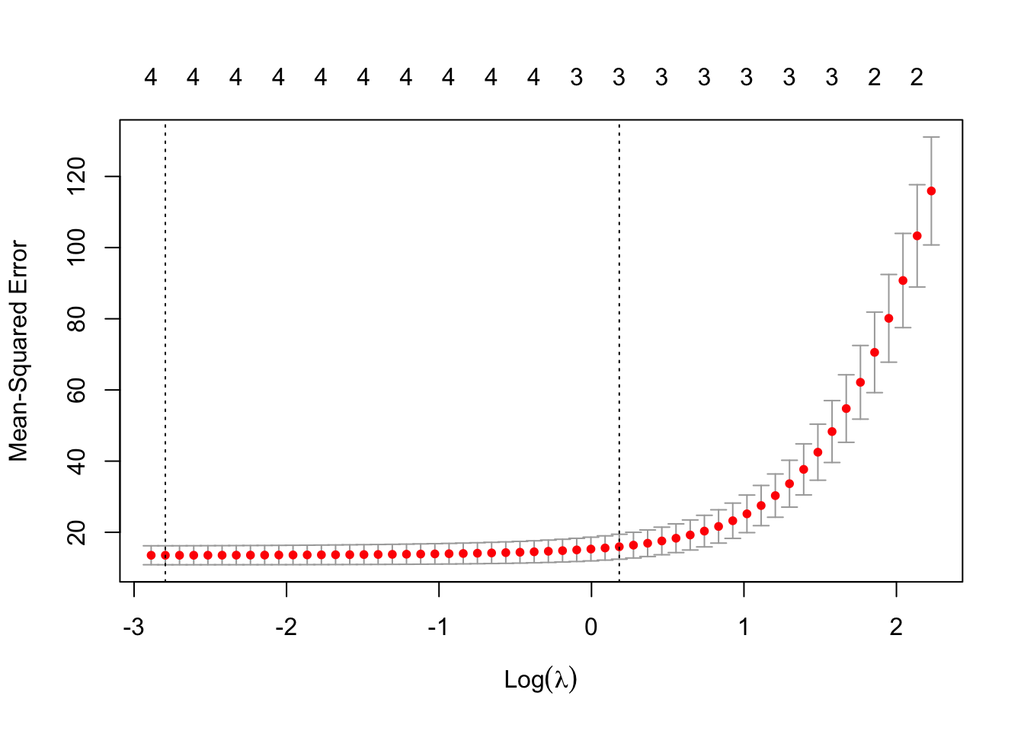

```r
set.seed(12)
cv.lasso=cv.glmnet(x, y, alpha = 1, nfolds = 10)
plot(cv.lasso)
```

we are interested only in the location of the minimum point in the estimated test MSE

Value of lambda that minimizes Cross-Validation Error, Associated coefficients and MSE

```r
# λ
bestlam <- cv.lasso$lambda.min
bestlam
```

```
## [1] 0.06112484
```

```r
# Associated coefficients
coef(cv.lasso, s = bestlam)
```

```
## 6 x 1 sparse Matrix of class "dgCMatrix"
##                     s1
## (Intercept)  2.3836468
## INTERNET     0.1713687
## CO2          0.7316487
## CELLULAR     0.1393206
## FERTILITY   -0.3450025
## LITERACY     .
```

```r
# Associated MSE
cv.lasso$cvm[cv.lasso$lambda == bestlam]
```

```
## [1] 13.54812
```

## k=5 folds

Since our dataset consist of 39 observations we can try to perform Cross-Validation with k=5 folds and compare the error of the 2 model with the minimum error in both procedures

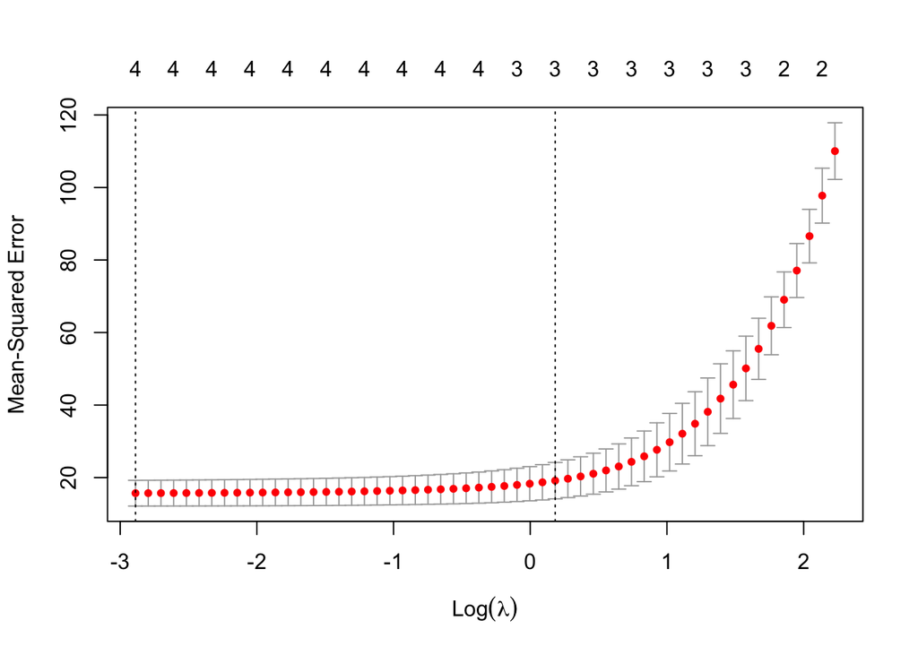

```r
set.seed(12)
cv.lasso2=cv.glmnet(x, y, alpha = 1, nfolds = 5)
plot(cv.lasso2)
```

```r
# λ
bestlam2 <- cv.lasso2$lambda.min
bestlam2
```

```
## [1] 0.05569467
```

```r
# Associated coefficients
coef(cv.lasso2, s = bestlam2)
```

```
## 6 x 1 sparse Matrix of class "dgCMatrix"
##                     s1
## (Intercept)  2.3821381
## INTERNET     0.1714008
## CO2          0.7322514
## CELLULAR     0.1393730
## FERTILITY   -0.3472971
## LITERACY     .
```

```r
# Associated MSE
cv.lasso2$cvm[cv.lasso2$lambda == bestlam2]
```

```
## [1] 15.69554
```

The LASSO with k=10 has a lower MSE

## Forward stepwise selection

### Best subset selection

We fit all p models that contain exactly one predictor, all $\binom{p}{2} = \frac{p(p-1)}{2}$ models that contain exactly two predictors, and so forth. The problem of selecting the best model from among the 2p possibilities considered by best subset selection is not trivial.

### Forward stepwise selection

is a computationally efficient alternative to best subset selection. While the best subset selection procedure considers all $2^p$ possible models containing subsets of the p predictors, forward stepwise considers a much smaller set of models. Forward stepwise selection begins with a model containing no predictors, and then adds predictors to the model, one-at-a-time, until all of the predictors are in the model. In particular, at each step the variable that gives the greatest additional improvement to the fit is added to the model.

```r
regfit.fwd <- regsubsets(GDP ~ . - COUNTRY, data = data, nvmax = 5, method = "forward")
reg.fwd.summary <- summary(regfit.fwd)
reg.fwd.summary
```

```
## Subset selection object
## Call: regsubsets.formula(GDP ~ . - COUNTRY, data = data, nvmax = 5,
##     method = "forward")
## 5 Variables  (and intercept)
##           Forced in Forced out
## INTERNET      FALSE      FALSE
## CO2           FALSE      FALSE
## CELLULAR      FALSE      FALSE
## FERTILITY     FALSE      FALSE
## LITERACY      FALSE      FALSE
## 1 subsets of each size up to 5
## Selection Algorithm: forward
##          INTERNET CO2 CELLULAR FERTILITY LITERACY
## 1  ( 1 ) "*"      " " " "      " "       " "
## 2  ( 1 ) "*"      " " "*"      " "       " "
## 3  ( 1 ) "*"      "*" "*"      " "       " "
## 4  ( 1 ) "*"      "*" "*"      "*"       " "
## 5  ( 1 ) "*"      "*" "*"      "*"       "*"
```

### RSS

Here we can se the RSS in functiojon of the numbers of coefficients

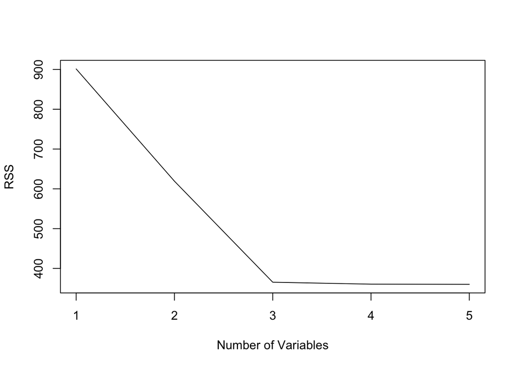

```r
plot(reg.fwd.summary$rss, xlab = "Number of Variables", ylab = "RSS", type = "l")
```

### Adjusted R^2

we know that th usual R^2 is defined as 1 − RSS/TSS

where:

$$TSS = \sum_{i=1}^{n} (y_i - \bar{y})^2$$

but since the RSS always decreases as more variables are added to the model, the R2 always increases as more variables are added. For a least squares model with d variables the adjusted R2 statistic is calculated as

$$Adjusted R^2 = 1 - \frac{\frac{\text{RSS}}{n - d -
1}}{\frac{\text{TSS}}{n - 1}}$$

Maximizing the adjusted R2 is equivalent to minimizing RSS/(n-d-1) While RSS always decreases as the number of variables in the model increases, RSS/(n-d-1) may increase or decrease, due to the presence of d in the denominator

in theory, the model with the largest adjusted R2 will have only correct variables and no noise variables, the adjusted R^2 statistic pays a price for the inclusion of unnecessary variables in the model (unlike the classic R^2)

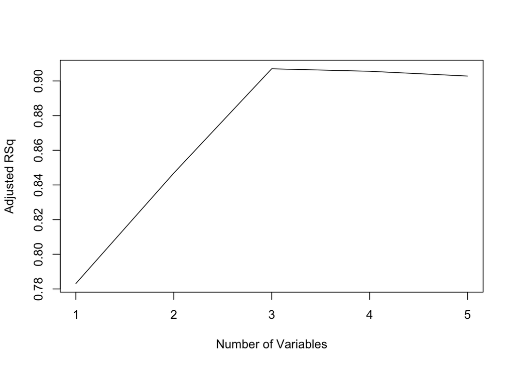

```r
plot(reg.fwd.summary$adjr2, xlab = "Number of Variables", ylab = "Adjusted RSq", type = "l")
```

```r
# Adjusted R^2
reg.fwd.summary$adjr2[which.max(reg.fwd.summary$adjr2)]
```

```
## [1] 0.9070306
```

### Mallow’s Cp

For a fitted least squares model containing d predictors, the Cp estimate of test MSE is computed using the equation

$$C_p = \frac{1}{n} (\text{RSS} + 2d \hat{\sigma}^ 2)$$

Typically σˆ2 is an estimate of the variance of the error ε adn it is estimated using the full model containing all predictors

Cp statistic adds a penalty of 2dσˆ2 to the training RSS in order to adjust for the fact that the training error tends to underestimate the test error. The penalty increases as the number of predictors in the model increases, this is intended to adjust for the corresponding decrease in training RSS

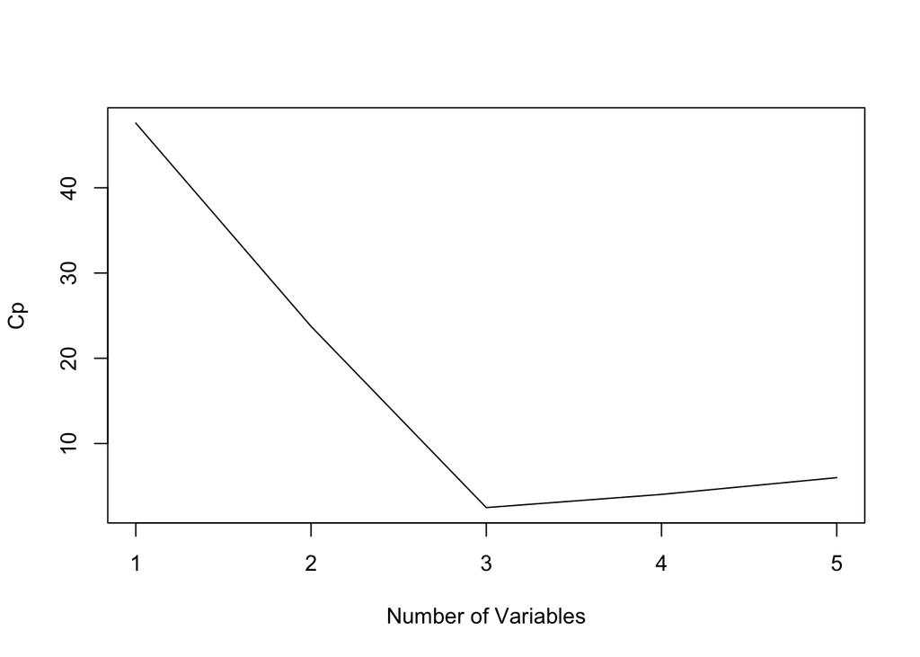

```r
plot(reg.fwd.summary$cp, xlab = "Number of Variables", ylab = "Cp", type = "l")
```

```r
# Cp
reg.fwd.summary$cp[which.min(reg.fwd.summary$cp)]
```

```
## [1] 2.485856
```

### Bayesian INfromation Criterion (BIC)

$$\text{BIC} = \frac{1}{n} \left( \text{RSS} + \log(n) d \hat{\sigma}^2
\right)$$

BIC replaces the 2dσˆ2 used by Cp with a log(n)dσˆ2 term, where n is the number of observations. Since log n > 2 for any n > 7, the BIC statistic generally places a heavier penalty on models with many variables

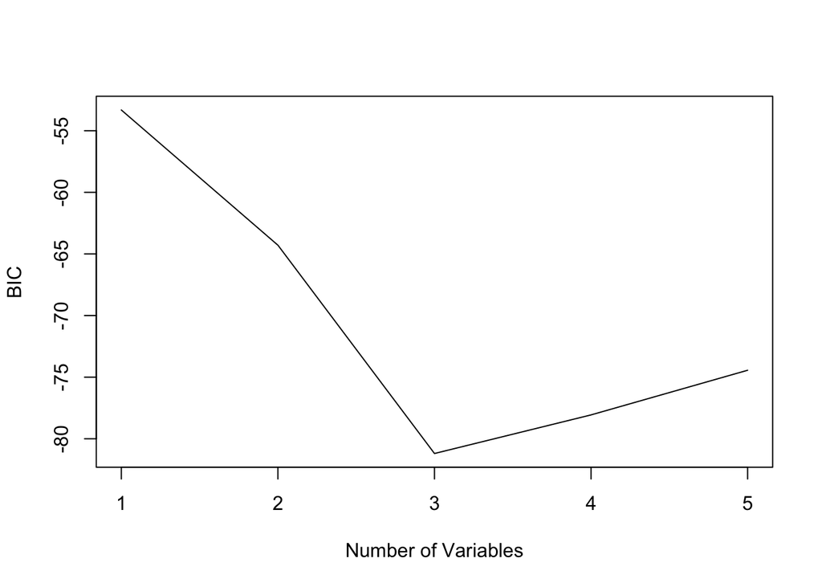

```r
plot(reg.fwd.summary$bic, xlab = "Number of Variables", ylab = "BIC", type = "l")
```

```r
# BIC
reg.fwd.summary$bic[which.min(reg.fwd.summary$bic)]
```

```
## [1] -81.19696
```

## Forward stepwise selection with Cross-Validation

As we have seen before for the lasso, now we use cross-validation to assess the model’s predictive performance on unseen data.

So while forward stepwise selection helps to quickly identify a subset of predictors that explains the response variable well, through the cross-validation we can evaluate the predictive performance of the selected models

```r
set.seed(12)
k <- 10
folds <- sample(rep(1:k, length = nrow(data)))
cv.errors <- matrix(NA, k, 5) # matrix with k rows and 5 columns
table(folds)
```

```
## folds
##  1  2  3  4  5  6  7  8  9 10
##  4  4  4  4  4  4  4  4  4  3
```

Let’s use this function (prof function)…

this function simply takes a model fitted by regsubsets, applies it to new data, and generates predictions based on the chosen subset of predictors

```r
predict.regsubsets <- function(object, newdata, id, ...) {
  form = as.formula(object$call[[2]])
  mat = model.matrix(form, newdata)
  coefi = coef(object, id = id)
  mat[, names(coefi)] %*% coefi
}
```

… in this Cross-validation loop (always provided by prof)

this loop performs the k-fold cross-validation to evaluate the predictive performance of forward stepwise regression models with different numbers of predictors from 1 to 5, fitting the model on the training folds and evaluating it on the test fold

```r
for (j in 1:k) {
  best.fit <- regsubsets(GDP ~ . - COUNTRY, data = data[folds != j, ], nvmax = 5, method = "forward")
  for (i in 1:5) {
    pred = predict.regsubsets(best.fit, data[folds == j, ], id = i)
    cv.errors[j, i] = mean((data$GDP[folds == j] - pred)^2)
  }
}
```

### Root mean squared error for CV errors

RMSE is on the same scale as the response variable

RMSE=√MSE

$$\text{RMSE} = \sqrt{\text{CV}(k)} = \sqrt{\frac{1}{k} \sum_{i=1}^{k}
\text{MSE}_i}$$

```r
rmse.cv = sqrt(apply(cv.errors, 2, mean))
summary(rmse.cv)
```

```
##    Min. 1st Qu.  Median    Mean 3rd Qu.    Max.
##   3.596   3.631   3.662   4.397   4.894   6.200
```

```r
plot(1:5, rmse.cv, type = "b", pch = 19, xlab = "Number of Variables", ylab = "RMSE" )
which.min(rmse.cv)
```

```
## [1] 3
```

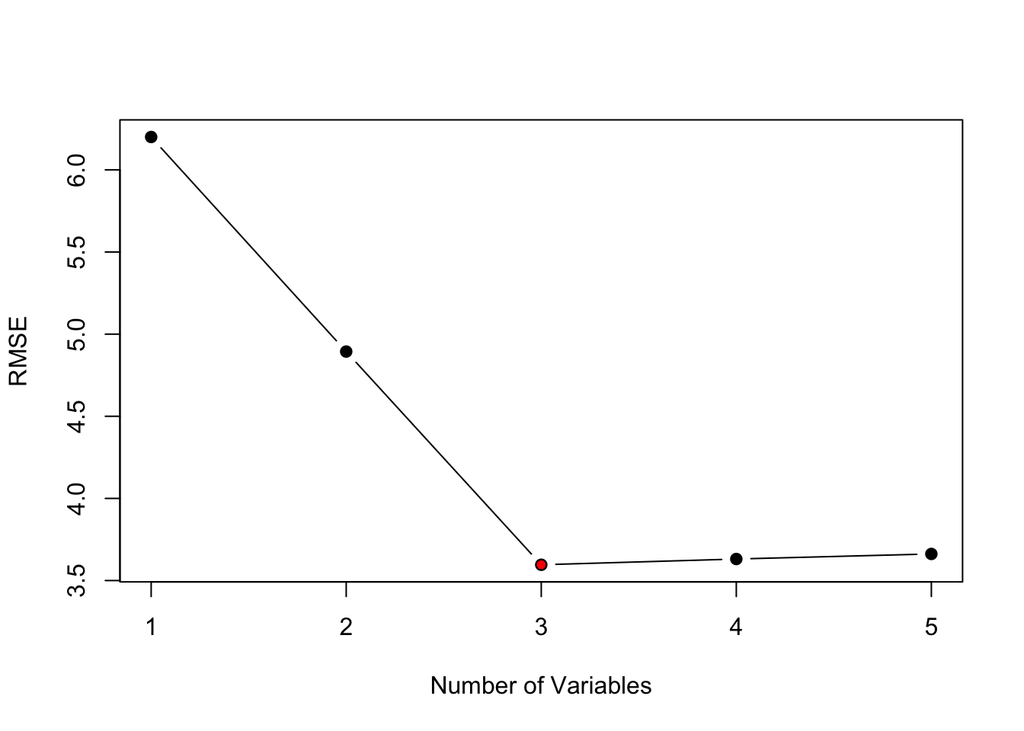

```r
points(3, rmse.cv[3], pch = 20, col = "red")
```

#### CV selects the 3 variables model

We now re-run Forward stepwise selection

```r
regfit.best <- regsubsets(GDP ~ . - COUNTRY, data = data, nvmax = 5, method = "forward")
```

and choose 3 as the number of variables

```r
coef(regfit.best, 3)
```

```
## (Intercept)    INTERNET         CO2    CELLULAR
##   1.0603382   0.1731283   0.7543997   0.1467387
```

## Beyond Linearity

Linear models are useful but they can be too simplistic for capturing complex relationships in the data.

### Step-functions

Step functions cut the range of a variable into K distinct regions in order to produce a qualitative variable. This has the effect of fitting a piecewise constant function

Polynomial functions imposes a global structure on the non-linear function of X.

With step functions we can avoid imposing such a global structure since we break the range of X into bins, and fit a different constant in each bin.

we create cutpoints c1, c2, . . . , cK in the range of X, and then construct K + 1 new variables

C0(X) = I(X < c1)

C1(X) = I(c1 ≤ X < c2)

C2(X) = I(c2 ≤ X < c3)

Ck(X) = I(ck ≤ X)

where I() is an indicator function that returns a 1 if the condition is true and 0 otherwise

Example: I(cK ≤ X) equals 1 if cK ≤ X, and equals 0 otherwise

note that

for any value of X, C0(X)+C1(X)+···+CK(X) = 1, since X must be in exactly one of the K + 1 intervals

But here we have a problem that is the discontinuities at the interval boundaries and inability to capture smooth transitions between intervals.

### Basis functions

Basis functions are a set of functions used to transform the original predictor variable into a new space where non-linear relationships can be modeled linearly. They can take various forms, including polynomials, splines, and step functions.

Instead of fitting a linear model in X we fit the model

$$y_i = \beta_0 + \beta_1 b_1(x_i) + \beta_2 b_2(x_i) + \beta_3 b_3(x_i) +
\cdots + \beta_K b_K(x_i) + \epsilon_i$$

so step function is a special case where bj(xi) = I(cj ≤ xi < cj+1)

## Constraints and Splines

Instead of fitting a high-degree polynomial over the entire range of X, piecewise polynomial regression involves fitting separate low-degree polynomials over different regions of X.

For example immagine to fit a cubic regression model

$$y_i = \beta_0 + \beta_1 x_i + \beta_2 x_i^2 + \beta_3 x_i^3 + \epsilon_i$$

where the coefficients β0, β1, β2, and β3 differ in different parts of the range of X.

#### Knots

the points where the coefficients change are called knots

A piecewise cubic polynomial with a single knot at a point c takes the form

If $x_i < c$,
$$y_i = \beta_{01} + \beta_{11} x_i + \beta_{21}
x_i^2 + \beta_{31} x_i^3 + \epsilon_i$$

If $x_i \geq c$,
$$y_i = \beta_{02} + \beta_{12} x_i + \beta_{22}
x_i^2 + \beta_{32} x_i^3 + \epsilon_i$$

we fit two different polynomial functions to the data, one on the subset of the observations with xi < c, and one on the subset of the observations with xi ≥ c

more knots = more flexible piecewise polynomial

### Constraints

The problem is that the function can has some jumps at the knot

To remedy this problem we can fit a piecewise polynomial under some constraints (e.g 1st and 2nd derivatives continuous)

Note that each constraint that we impose on the piecewise cubic polynomials reduces one degree of freedom, by reducing the complexity of the resulting piecewise polynomial fit, that’s because each constraint reduces the number of free parameters that need to be estimated.

### Splines

flexible class of basis functions

Splines are a way to fit a flexible curve to data by breaking it into pieces and fitting separate polynomials to each piece.

Degree-d spline: it is a piecewise degree-d polynomial, with continuity in derivatives up to degree d − 1 at each knot. A degree-d spline means that in each segment between the knots we fit a polynomial of degree d

[e.g a linear spline is obtained by fitting a line in each region of the predictor space defined by the knots requiring continuity (no jump) at each knot]

SPlines have high variance at the boundaries (the smallest and largest value of x)

Natural spline: is a regression spline with additional boundary constraints that is, the function is required to be linear at the boundary

#### where place the knots?

it is common to place knots in a uniform fashion.

We specify the desired degrees of freedom, and then R will automatically place the corresponding number of knots at uniform quantiles of the data

So in our context degrees of freedom (df) control the flexibility of the spline and we can think about df as the number of basis function to represent the spline

## Generalized Additive Model

Generalized additive models (GAMs) provide a general framework for extending a standard linear model by allowing non-linear functions of each of the variables,while maintaining additivity.

In other words yhe effects of the predictor variables on the response variable are added together, even though these effects can be non-linear

$$y = \beta_0 + f_1(x_1) + f_2(x_2) + \cdots + f_p(x_p) + \epsilon$$

where ƒj(xj) are smooth non-linear functions

so we can see now the sense of “ADDITIVE”, since we compute a separate ƒj for eax xj and then add together all of their contributions

We are going to use the `gam` package since it makes it easier to work with multiple nonlinear terms and it knows how to plot these functions and their standard errors.

Now we fit different models with different splines

```r
gam_model_lit_df2 <- gam(FERTILITY ~ GDP + s(LITERACY, df=2), data = data)
gam_model_lit_df3 <- gam(FERTILITY ~ GDP + s(LITERACY, df=3), data = data)
gam_model_lit_df4 <- gam(FERTILITY ~ GDP + s(LITERACY, df=4), data = data)
gam_model_lit_df5 <- gam(FERTILITY ~ GDP + s(LITERACY, df=5), data = data)
gam_model_lit_df6 <- gam(FERTILITY ~ GDP + s(LITERACY, df=6), data = data)
gam_model_lit_df7 <- gam(FERTILITY ~ GDP + s(LITERACY, df=7), data = data)
gam_model_lit_df8 <- gam(FERTILITY ~ GDP + s(LITERACY, df=8), data = data)
gam_model_lit_df9 <- gam(FERTILITY ~ GDP + s(LITERACY, df=9), data = data)
gam_model_lit_df10 <- gam(FERTILITY ~ GDP + s(LITERACY, df=10), data = data)
```

Let’s compare our models using ANOVA

```r
anova_lit <- anova(gam_model_lit_df2, gam_model_lit_df3, gam_model_lit_df4, gam_model_lit_df5, gam_model_lit_df6,gam_model_lit_df7, gam_model_lit_df8,gam_model_lit_df9, gam_model_lit_df10)
print(anova_lit)
```

```
## Analysis of Deviance Table
##
## Model 1: FERTILITY ~ GDP + s(LITERACY, df = 2)
## Model 2: FERTILITY ~ GDP + s(LITERACY, df = 3)
## Model 3: FERTILITY ~ GDP + s(LITERACY, df = 4)
## Model 4: FERTILITY ~ GDP + s(LITERACY, df = 5)
## Model 5: FERTILITY ~ GDP + s(LITERACY, df = 6)
## Model 6: FERTILITY ~ GDP + s(LITERACY, df = 7)
## Model 7: FERTILITY ~ GDP + s(LITERACY, df = 8)
## Model 8: FERTILITY ~ GDP + s(LITERACY, df = 9)
## Model 9: FERTILITY ~ GDP + s(LITERACY, df = 10)
##   Resid. Df Resid. Dev      Df Deviance Pr(>Chi)
## 1        35    16.5823
## 2        34    15.0515 0.99995  1.53079  0.02269 *
## 3        33    13.2069 0.99990  1.84460  0.01237 *
## 4        32    11.6310 1.00016  1.57595  0.02078 *
## 5        31    10.6892 0.99990  0.94171  0.07389 .
## 6        30    10.0501 1.00009  0.63913  0.14094
## 7        29     9.4059 0.99969  0.64423  0.13930
## 8        28     8.6987 0.99996  0.70714  0.12145
## 9        27     7.9604 1.00006  0.73835  0.11354
## ---
## Signif. codes:  0 '***' 0.001 '**' 0.01 '*' 0.05 '.' 0.1 ' ' 1
```

Here we look for a balanced model with low residual deviance and low p-value which tells if the reduction in deviance is statistically significant.

The residual deviance is a measure of the difference between the observed data and the values predicted by the model, it quantifies the error or lack of fit of the model.

Results suggest that df=5 is a good choice since beyond this models, the reductions in deviance are not statistically significant, indicating that additional complexity does not provide a significant improvement in the model fit.

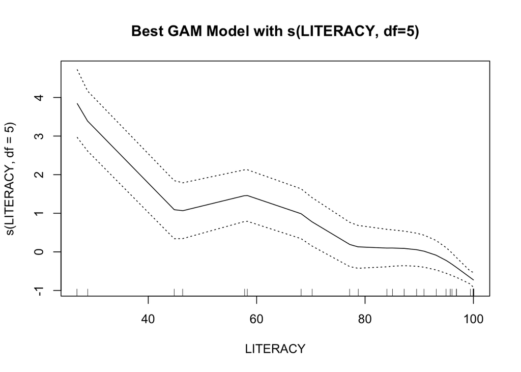

```r
best_model_lit <- gam(FERTILITY ~ s(LITERACY, df=5), data = data)
plot(best_model_lit, se=T, main="Best GAM Model with s(LITERACY, df=5)")
```

This plots represents the estimated smooth function for LITERACY and tells us how FERTILITY changes as LITERACY increases.

The dashed lines represent the 95% confidence intervals around the smooth function, that is the range within which we expect the true relationship between literacy and fertility to fall, with 95% confidence

the vertical lines along the x-axis indicate the distribution of LITERACY values in the dataset, so where the actual data points are concentrated

## Fertility

### Discretize fertility

Let’s create a new variable using ‘ifelse’ function, it will be a dummy variable which takes value of 1 if FERTILITY > 2 and 0 otherwise

```r
FERTILITY_CLASS <- ifelse(data$FERTILITY > 2, 1, 0)
# add it to  dataset
data$FERTILITY_CLASS <- FERTILITY_CLASS
```

Let’s also specufy the type of this variable and see how the observations have been classified

```r
data$FERTILITY_CLASS <- as.factor(data$FERTILITY_CLASS)
table(data$FERTILITY_CLASS)
```

```
##
##  0  1
## 20 19
```

## TASK 6 and TASK 7

Let’s divide our dataset into ‘training set’ and ‘test set’

```r
train_data <- data[1:25, ]
test_data <- data[26:nrow(data), ]
```

## Logistic model

Logistic regression models the probability that Y belongs to a particular category.

$$p(X) = \frac{e^{\beta_0 + \beta_1 X_1 + \cdots + \beta_p X_p}}{1 +
e^{\beta_0 + \beta_1 X_1 + \cdots + \beta_p X_p}}$$

or equivalently

$$\log\left(\frac{p}{1-p}\right) = \beta_0 + \beta_1 X_1 + \beta_2 X_2 +
\cdots + \beta_p X_p$$

where left-hand side is called the log odds or logit

Values of the odds close to 0 and ∞ indicate very low and very high probabilities

The goal is to find β’s such that plugging these estimates into the model for p(X), it yields a number close to one for all observations that belong to the 1 class , and a number close to zero for the observations that belong to class 0

To fit the model we use maximum likelihood

To fit the logistic model we use the ‘glm’ function by specifying ‘family = binomial’ (on the training data)

```r
logistic_model <- glm(FERTILITY_CLASS ~ INTERNET + GDP + CO2 + CELLULAR + LITERACY, data = train_data, family = binomial)
summary(logistic_model)
```

```
##
## Call:
## glm(formula = FERTILITY_CLASS ~ INTERNET + GDP + CO2 + CELLULAR +
##     LITERACY, family = binomial, data = train_data)
##
## Coefficients:
##             Estimate Std. Error z value Pr(>|z|)
## (Intercept)  5.56138    6.23775   0.892    0.373
## INTERNET     0.00206    0.08059   0.026    0.980
## GDP         -0.39984    0.30233  -1.323    0.186
## CO2          0.05377    0.49338   0.109    0.913
## CELLULAR     0.03400    0.05076   0.670    0.503
## LITERACY    -0.01802    0.08014  -0.225    0.822
##
## (Dispersion parameter for binomial family taken to be 1)
##
##     Null deviance: 34.296  on 24  degrees of freedom
## Residual deviance: 13.369  on 19  degrees of freedom
## AIC: 25.369
##
## Number of Fisher Scoring iterations: 6
```

Here we can see the probability of each of the 14 test observations to belong to the 1 class (i.e. fertility > 2)

The type = “response” option tells R to output probabilities of the form P(Y = 1|X)

```r
glm_probs <- predict(logistic_model, newdata = test_data, type = "response")
glm_probs[1:14]
```

```
##           26           27           28           29           30           31
## 0.0085844670 0.9872016095 0.9470245396 0.8382016471 0.5047228088 0.6849826383
##           32           33           34           35           36           37
## 0.2071291955 0.0556689942 0.0096524834 0.9524653496 0.0618144573 0.0006978905
##           38           39
## 0.9601458391 0.9922123972
```

Now we are going to create a vector of the same length as our test dataset and then we transform to “>2” all of the elements for which the predicted probability of Y=1 exceeds 0.5

```r
glm_predictions <- rep("0", nrow(test_data))
glm_predictions[glm_probs > 0.5] <- "1"
```

Now let’s see our confusion matrix

```r
table(glm_predictions, test_data$FERTILITY_CLASS)
```

```
##
## glm_predictions 0 1
##               0 5 1
##               1 1 7
```

The 0 and 1 above the matrix represent the true class

The 0 and 1 at the side represent the predicted class

#### RECALL

0 corresponds to ‘<=2’ and 1 to ‘>2’

- true negatives = class is 0 and the predicted class is 0 (correctly predicted)
- false negatives = actual class is 1 and the predicted class is 0 (incorrectly predicted)
- true positives = actual class is 1 and the predicted class is 1 (correctly predicted)
- false positives = actual class is 0 and the predicted class is 1 (incorrectly predicted)

#### Accuracy (fraction of corrected predictions)

```r
logistic_accuracy1 <- mean(glm_predictions == test_data$FERTILITY_CLASS)
logistic_accuracy1
```

```
## [1] 0.8571429
```

#### training error

```r
training_error_logistic <- 1-mean(glm_predictions == test_data$FERTILITY_CLASS)
training_error_logistic
```

```
## [1] 0.1428571
```

Recall that the logistic regression model had very underwhelming p-values associated with all of the predictors, and that the smallest p-value, though not very small is associated with GDP

Let’s try to fit another model with just the “more” significant variable (i.e GDP)

```r
logistic_model2 <- glm(FERTILITY_CLASS ~ GDP, data = train_data, family = binomial)
glm_probs2 <- predict(logistic_model2, newdata = test_data, type = "response")
glm_probs2[1:14]
```

```
##          26          27          28          29          30          31
## 0.015966722 0.971952689 0.952857663 0.891387764 0.594494049 0.720426457
##          32          33          34          35          36          37
## 0.181983929 0.068043077 0.024105471 0.919792165 0.068394555 0.004405127
##          38          39
## 0.970563728 0.979154136
```

```r
glm_predictions2 <- rep("0", nrow(test_data))
glm_predictions2[glm_probs2 > 0.5] <- "1"
table(glm_predictions2, test_data$FERTILITY_CLASS)
```

```
##
## glm_predictions2 0 1
##                0 5 1
##                1 1 7
```

```r
logistic_accuracy2 <- mean(glm_predictions2 == test_data$FERTILITY_CLASS)
logistic_accuracy2
```

```
## [1] 0.8571429
```

```r
training_error2 <- 1-mean(glm_predictions2 == test_data$FERTILITY_CLASS)
training_error2
```

```
## [1] 0.1428571
```

The result is the same

## Bayes classifier

The Bayes classifier assigns an observation x to the class k that maximizes the posterior probability

$$P(Y=k\mid \mathbf{x}) = \frac{P(\mathbf{x} \mid Y=k) \,
P(Y=k)}{P(\mathbf{x})}$$

where:

- p(Y=k) is the PRIOR PROBABILITY of class k (relative frequency)
- p(x|Y=k) is the likelihood (depends on the assumptions)
- p(x) is the marginal probability of observing the data x across all classes, it is the sum of the likelihood of x over all possible classes, weighted by their prior probabilities

e.g. in case of k=2 classes with Y=0 and Y=1 p(x) = p(x|Y=0) p(Y=0) + p(x|Y=1) p(Y=1)

## Linear Discriminant Analysis

Here we just assume that the likelihood function [ p(x|Y=k) ] for the x’s is the normal one

The linear discriminant analysis assumes that X = (X1,X2,…,Xp) is drawn from a multivariate Gaussian (or multivariate normal) distribution, with a class-specific mean vector and a common covariance matrix (and so linear boundaries between the 2 classes)

Since we have p > 1, we assume that the observations in the kth class are drawn from a multivariate Gaussian distribution N(μk,Σ)

where

- μk is a class-specific mean vector
- Σ is a covariance matrix that is common to all K classes. This means that variance-covariance structure of the predictor variables is assumed to be the same regardless of whether the class for fertility is 0 or 1

NB: Because of the shared covariance matrix the decision boundaries between classes are linear

This assumptions allow LDA to estimate the parameters of the Gaussian distributions and to use these estimates to compute the posterior probabilities for the Bayes classifier

```r
lda_model <- lda(FERTILITY_CLASS ~ INTERNET + GDP + CO2 + CELLULAR + LITERACY, data = train_data)
lda_model
```

```
## Call:
## lda(FERTILITY_CLASS ~ INTERNET + GDP + CO2 + CELLULAR + LITERACY,
##     data = train_data)
##
## Prior probabilities of groups:
##    0    1
## 0.56 0.44
##
## Group means:
##    INTERNET       GDP      CO2 CELLULAR LITERACY
## 0 33.995714 23.776429 9.557143 63.71429 98.20000
## 1  8.853636  7.649091 3.663636 20.24545 74.89091
##
## Coefficients of linear discriminants:
##                   LD1
## INTERNET -0.013096914
## GDP      -0.164076888
## CO2       0.014951834
## CELLULAR  0.005683002
## LITERACY -0.001400256
```

#### Group means

are the average of each predictor within each class, and are used by LDA as estimates of μk. They are the average values of INTERNET, GDP, CO2, CELLULAR, and LITERACY for each class, which LDA uses as the class-specific mean vectors (µ0 and µ1)

#### Prior probabilities

Class 0 = based on the training data, there is an estimated 56% chance that any randomly chosen observation will have a fertility rate less than or equal to 2

Class 1 = based on the training data estimated 44% chance that any randomly chosen observation will have a fertility rate greater than 2

The prior probabilities are used to compute the posterior probabilities

#### Linear discriminant

The coefficients of linear discriminants output provides the linear combination of the predictors that are used to form the LDA decision rule

#### Predictions

In this case the ‘predict’ function directly provides predicted class labels, and posterior probabilities

```r
lda_predictions <- predict(lda_model, newdata = test_data)
names(lda_predictions)
```

```
## [1] "class"     "posterior" "x"
```

#### Confusion matrix

```r
lda_class <- lda_predictions$class
table(lda_class, test_data$FERTILITY_CLASS)
```

```
##
## lda_class 0 1
##         0 5 1
##         1 1 7
```

#### RECALL

0 corresponds to ‘<=2’ and 1 to ‘>2’

- true negatives = class is 0 and the predicted class is 0 (correctly predicted)
- false negatives = actual class is 1 and the predicted class is 0 (incorrectly predicted)
- true positives = actual class is 1 and the predicted class is 1 (correctly predicted)
- false positives = actual class is 0 and the predicted class is 1 (incorrectly predicted)

#### Posterior probabilities

Posterior probabilities that each observation belongs to the class 0

```r
lda_predictions$posterior[, 1]
```

```
##          26          27          28          29          30          31
## 0.998614707 0.002703749 0.006960916 0.023993690 0.211992590 0.118308926
##          32          33          34          35          36          37
## 0.836255472 0.989567385 0.996377600 0.013250381 0.977345979 0.999861842
##          38          39
## 0.003768838 0.001613538
```

```r
lda_class
```

```
##  [1] 0 1 1 1 1 1 0 0 0 1 0 0 1 1
## Levels: 0 1
```

#### Accuracy

```r
lda_accuracy <- mean(lda_class == test_data$FERTILITY_CLASS)
lda_accuracy
```

```
## [1] 0.8571429
```

#### Training error

```r
lda_train_error <- 1-mean(lda_class == test_data$FERTILITY_CLASS)
lda_train_error
```

```
## [1] 0.1428571
```

The results are the same as the Logistic model

## Quadratic Discriminant Analysis

In Quadratic Discriminant Analysis the approach is similar to LDA. However in QDA we relax the assumption that the covariance matrices of each class are the same. Instead, we assume that each class has its own covariance matrix ∑k allowing for a more flexible decision boundary that is quadratic and no more linear

```r
qda_model <- qda(FERTILITY_CLASS ~ INTERNET + GDP + CO2 + CELLULAR + LITERACY, data = train_data)
print(qda_model)
```

```
## Call:
## qda(FERTILITY_CLASS ~ INTERNET + GDP + CO2 + CELLULAR + LITERACY,
##     data = train_data)
##
## Prior probabilities of groups:
##    0    1
## 0.56 0.44
##
## Group means:
##    INTERNET       GDP      CO2 CELLULAR LITERACY
## 0 33.995714 23.776429 9.557143 63.71429 98.20000
## 1  8.853636  7.649091 3.663636 20.24545 74.89091
```

```r
qda_predictions <- predict(qda_model, newdata = test_data)
qda_class <- qda_predictions$class
table(qda_class, test_data$FERTILITY_CLASS)
```

```
##
## qda_class 0 1
##         0 5 2
##         1 1 6
```

#### Accuracy

```r
qda_accuracy <- mean(qda_class == test_data$FERTILITY_CLASS)
```

#### Training error

```r
qda_train_error <- 1 - mean(qda_class == test_data$FERTILITY_CLASS)
qda_train_error
```

```
## [1] 0.2142857
```

But this model is less precise, this may be due to the increased flexibility which can sometimes lead to overfitting, especially with smaller datasets.

## K-nearest neighbors (KNN)

KNN is a non-parametric method this means that it does not make any assumptions about the underlying data distribution

Given a positive integer K and a test observation x0, the KNN classifier first identifies the K points in the training data that are closest to x0, represented by N0 It then estimates the conditional probability for class j as the fraction of points in N0 whose response values equal j

KNN classifies the test observation x0 to the class with the largest

$$\Pr(Y = j \mid X = x_0) = \frac{1}{K} \sum_{i \in N_0} I(y_i = j)$$

The goal is to estimate the probability that the class label Y is j given that X=x0

So it counts how many of the K nearest neighbors in N0 have the class label j

Note that I(yi=j) = 1 if class label of the i-th neighbors is j, and I(yi=j) = 0 otherwise

Here the procedure of the book is followed ( Lab section 4.7.6 ), first we perform KNN without standardization and then we standardize the data to see if some differences arise.

We will now perform KNN using the knn() function. This function works differently from the other model functions that we have used. It does NOT perform a two-step approach in which first it fits the model and then it uses the model to make predictions. knn() forms predictions using a single command, it requires 4 inputs

1. A matrix containing the predictors associated with the TRAINING data
2. A matrix containing the predictors associated with the TEST
3. A vector containing the class labels for the training observations
4. A value for K, the number of nearest neighbors to be used by the classifier.

Let’s set up the necessary variables

```r
train.X <- cbind(train_data$INTERNET, train_data$GDP, train_data$CO2, train_data$CELLULAR, train_data$LITERACY)
test.X <- cbind(test_data$INTERNET, test_data$GDP, test_data$CO2, test_data$CELLULAR, test_data$LITERACY)
train.FERTILITY_CLASS <- train_data$FERTILITY_CLASS
```

### K = 1

With k=1, for a given test observation x0 the classifier identifies the single closest point xi in the training data to x0 and then the class of the nearest neighbor xi is assigned as the predicted class for the test observation x0

```r
set.seed(12)
knn.pred <- knn(train.X, test.X, train.FERTILITY_CLASS, k = 1)
table(knn.pred, test_data$FERTILITY_CLASS)
```

```
##
## knn.pred 0 1
##        0 5 2
##        1 1 6
```

#### Accuracy

```r
knn_accuracy <- mean(knn.pred == test_data$FERTILITY_CLASS)
knn_accuracy
```

```
## [1] 0.7857143
```

#### Error rate

```r
knn_error_rate <- 1 - knn_accuracy
knn_error_rate
```

```
## [1] 0.2142857
```

### K = 2

Let’s see what happen when considering K=2 nearest observations

```r
set.seed(12)
knn.pred2 <- knn(train.X, test.X, train.FERTILITY_CLASS, k = 2)
table(knn.pred2, test_data$FERTILITY_CLASS)
```

```
##
## knn.pred2 0 1
##         0 5 1
##         1 1 7
```

#### Accuracy

```r
knn_accuracy2 <- mean(knn.pred2 == test_data$FERTILITY_CLASS)
knn_accuracy2
```

```
## [1] 0.8571429
```

### Error rate

```r
knn_error_rate2 <- 1 - knn_accuracy2
knn_error_rate2
```

```
## [1] 0.1428571
```

### Standardization

Because the KNN classifier predicts the class of a given test observation by identifying the observations that are nearest to it, the scale of the variables matters. Variables that are on a large scale will have a much larger effect on the distance between the observations, and hence on the KNN classifier, than variables that are on a small scale.

A good way to handle this problem is to standardize the data so that all variables are given a mean of zero and a standard deviation of one. Then all variables will be on a comparable scale. The ‘scale()’ function does just this.

So let’s standardize our data

```r
data_normalized <- data
data_normalized[, c("INTERNET", "GDP", "CO2", "CELLULAR", "LITERACY")] <- scale(data[, c("INTERNET", "GDP", "CO2", "CELLULAR", "LITERACY")])
train_data_normalized <- data_normalized[1:25, ]
test_data_normalized <- data_normalized[26:39, ]
```

```r
st.train.X <- train_data_normalized[, c("INTERNET", "GDP", "CO2", "CELLULAR", "LITERACY")]
st.test.X <- test_data_normalized[, c("INTERNET", "GDP", "CO2", "CELLULAR", "LITERACY")]
```

### K=2

```r
set.seed(12)
st.knn.pred <- knn(st.train.X, st.test.X, train.FERTILITY_CLASS, k = 2)
table(st.knn.pred, test_data_normalized$FERTILITY_CLASS)
```

```
##
## st.knn.pred 0 1
##           0 5 1
##           1 1 7
```

#### Accuracy

```r
mean(st.knn.pred == test_data_normalized$FERTILITY_CLASS)
```

```
## [1] 0.8571429
```

#### Error rate

```r
1-mean(st.knn.pred == test_data_normalized$FERTILITY_CLASS)
```

```
## [1] 0.1428571
```

The results don’t change even if we try higher levels of K